# Exercise #2

Fortgeschrittene Statistische Software für NF

Akram Helal, Seyed Ramtin Hosseini (12781949), Necati Deniz Baykuş  
2025-05-22

## General Remarks

- You can submit your solutions in teams of up to 3 students.
- Include all your team-member’s names and student numbers (Martrikelnummern) in the `authors` field.
- Please use the exercise template document to work on and submit your results.
- Use a level 2 heading for each new exercise and answer each subtask next to it’s bullet point or use a new level 3 heading if you want.
- Always render the R code for your solutions and make sure to include the resulting data in your rendered document.
  - Make sure to not print more than 10 rows of data (unless specifically instructed to).
- Always submit both the rendered document(s) as well as your source Rmarkdown/Quarto document. Submit the files separately on moodle, **not** as a zip archive.
- Submission format is HTML. Other formats will lead to a deduction of points.

### Installing and loading librarys.

```r
#install.packages("report")

library(tidyverse)
library(knitr)
library(kableExtra)
library(report)
library(ggeffects)
```

## Exercise 1: Linear Regression (8 Points)

In this exercise we will use the `LeTourDataSet` dataset from this repository: https://github.com/thomascamminady/LeTourDataSet.

1. Make yourself familiar with the data and look in the [repository](https://github.com/thomascamminady/LeTourDataSet) to read how to load it into R. To access the data you might need to install the `"remotes"` package.

Loading the data-set from Github, as stated in the README section to get the data.

```r
# Men's Tour de France data
tdf_men <- read_csv("https://raw.githubusercontent.com/thomascamminady/LeTourDataSet/master/data/TDF_Riders_History.csv")

# Women's Tour de France data
tdf_women <- read_csv("https://raw.githubusercontent.com/thomascamminady/LeTourDataSet/master/data/TDFF_Riders_History.csv")
```

2. Create a variable that, for each male rider, calculates the total distance they participated in across all years. Then, show the top 10 riders who covered the most distance. For each rider, calculate the average distance they participated in per year. Then, create a variable that is 1 if the rider’s average distance is above the overall average across all riders, and 0 otherwise.

```r
# Calculating total distance over years for each rider.
rider_men_summary <- tdf_men %>%
                     group_by(Rider) %>%
                     summarise(
                       total_distance = sum(`Distance (km)`, na.rm = TRUE)
                     )

# Arranging Coloumns desc.
rider_men_summary <- rider_men_summary %>%
  arrange(desc(total_distance))

# Showing the table
knitr::kable(
  head(rider_men_summary, 10),
  col.names = c("Rider", "Total Distance"),
  caption = "Top-10 Riders by total distance across all participated years",
  format = "html",
  booktabs = TRUE
) %>%
  kable_styling(
    bootstrap_options = c("striped", "hover", "condensed")
  ) %>%
  row_spec(0, bold = TRUE, background = "#D3D3D3")
```

Table 1: Top-10 Riders by total distance across all participated years

| Rider | Total Distance |
| --- | --- |
| LUCIEN VAN IMPE | 59312 |
| JOOP ZOETEMELK | 58719 |
| SYLVAIN CHAVANEL | 55926 |
| VJATCESLAV EKIMOV | 55191 |
| STUART O’GRADY | 53691 |
| ANDRÉ DARRIGADE | 53007 |
| THOMAS VOECKLER | 52908 |
| HAIMAR ZUBELDIA | 52611 |
| RAYMOND POULIDOR | 50544 |
| JENS VOIGT | 50152 |

```r
# Calculating average distance of each rider for each year participated in
rider_men_summary_distinct <- tdf_men %>%
  group_by(Rider) %>%
  summarise(
    total_distance = sum(`Distance (km)`, na.rm = TRUE),
    avg_distance_per_year = round(total_distance / n_distinct(Year), 2)
    )

# Calculating a binary varible to check if the average distance of the rider is  above or below the average of all riders
# Average across all rider
overall_avg = mean(rider_men_summary_distinct$avg_distance_per_year, na.rm = TRUE)

rider_men_summary_distinct <- rider_men_summary_distinct %>%
  mutate(
    above_average = if_else(avg_distance_per_year > overall_avg, 1, 0)
    )

# Arranging Coloumns desc.
rider_men_summary_distinct <- rider_men_summary_distinct %>%
  arrange(desc(total_distance))

# Showing the table
knitr::kable(
  head(rider_men_summary_distinct, 10),
  col.names = c("Rider", "Total Distance", "Average Distance per year", "Above Average"),
  caption = "Top-10 Riders by average distance across all participated years ",
  format = "html",
  booktabs = TRUE
) %>%
  kable_styling(
    bootstrap_options = c("striped", "hover", "condensed")
  ) %>%
  row_spec(0, bold = TRUE, background = "#D3D3D3")
```

| Rider | Total Distance | Average Distance per year | Above Average |
| --- | --- | --- | --- |
| LUCIEN VAN IMPE | 59312 | 3954.13 | 0 |
| JOOP ZOETEMELK | 58719 | 3914.60 | 0 |
| SYLVAIN CHAVANEL | 55926 | 3495.38 | 0 |
| VJATCESLAV EKIMOV | 55191 | 3679.40 | 0 |
| STUART O’GRADY | 53691 | 3579.40 | 0 |
| ANDRÉ DARRIGADE | 53007 | 4417.25 | 1 |
| THOMAS VOECKLER | 52908 | 3527.20 | 0 |
| HAIMAR ZUBELDIA | 52611 | 3507.40 | 0 |
| RAYMOND POULIDOR | 50544 | 4212.00 | 1 |
| JENS VOIGT | 50152 | 3582.29 | 0 |

3. Run a linear regression using each male rider’s average distance as the **dependent variable**. Use the following four **independent variables**: • The first year they participated (first_year) • The total number of participations (num_participations) • Their average total race time in hours (avg_total_hours) • A binary variable is_2020_rider that is 1 if they ever rode in 2020, otherwise 0

```r
# Function to convert "hh h mm' ss''" format to hours
convert_time_to_hours <- function(time_str) {
  # Extract hours, minutes, and seconds
  matches <- regmatches(time_str, regexec("(\\d+)h (\\d+)' (\\d+)''", time_str))
  sapply(matches, function(x) {
    if (length(x) == 4) {
      hours <- as.numeric(x[2])
      minutes <- as.numeric(x[3])
      seconds <- as.numeric(x[4])
      total_hours <- hours + minutes / 60 + seconds / 3600
      return(total_hours)
      } else {
        return(NA)
        }
    })
}
```

```r
rider_features <- tdf_men %>%
                  group_by(Rider) %>%
                  summarise(
                    first_year = min(Year),
                    num_participations = n_distinct(Year),
                    avg_total_time = mean(convert_time_to_hours(Times)),
                    total_distance = sum(`Distance (km)`, na.rm = TRUE),
                    avg_distance_per_year = round(total_distance / n_distinct(Year), 2),
                    is_2020_rider = as.integer(any(Year == 2020)),
                    .groups = "drop"
                  )
```

```r
# Regression Model
lr_model <- lm(
      formula = avg_distance_per_year ~ first_year + num_participations +  avg_total_time + is_2020_rider, data = rider_features)
summary(lr_model)
```

```
Call:
lm(formula = avg_distance_per_year ~ first_year + num_participations +
    avg_total_time + is_2020_rider, data = rider_features)

Residuals:
    Min      1Q  Median      3Q     Max
-2590.7  -106.9    -6.1   147.3  1114.5

Coefficients:
                     Estimate Std. Error t value Pr(>|t|)
(Intercept)        27050.0354   500.0697  54.093   <2e-16 ***
first_year           -11.7645     0.2485 -47.350   <2e-16 ***
num_participations    -4.5942     2.6033  -1.765   0.0777 .
avg_total_time         1.8972     0.1191  15.927   <2e-16 ***
is_2020_rider        -28.6748    31.4871  -0.911   0.3625
---
Signif. codes:  0 '***' 0.001 '**' 0.01 '*' 0.05 '.' 0.1 ' ' 1

Residual standard error: 353.2 on 3546 degrees of freedom
Multiple R-squared:  0.6523,    Adjusted R-squared:  0.652
F-statistic:  1663 on 4 and 3546 DF,  p-value: < 2.2e-16
```

4. Use the appropriate easystats package to automatically generate a report of the model you created.

```r
report(lr_model)
```

```
We fitted a linear model (estimated using OLS) to predict
avg_distance_per_year with first_year, num_participations,
avg_total_time and is_2020_rider (formula: avg_distance_per_year ~
first_year + num_participations + avg_total_time + is_2020_rider).
The model explains a statistically significant and substantial
proportion of variance (R2 = 0.65, F(4, 3546) = 1663.46, p < .001,
adj. R2 = 0.65). The model's intercept, corresponding to first_year =
0, num_participations = 0, avg_total_time = 0 and is_2020_rider = 0,
is at 27050.04 (95% CI [26069.58, 28030.49], t(3546) = 54.09, p <
.001). Within this model:

  - The effect of first year is statistically significant and negative
(beta = -11.76, 95% CI [-12.25, -11.28], t(3546) = -47.35, p < .001;
Std. beta = -0.65, 95% CI [-0.67, -0.62])
  - The effect of num participations is statistically non-significant
and negative (beta = -4.59, 95% CI [-9.70, 0.51], t(3546) = -1.76, p
= 0.078; Std. beta = -0.02, 95% CI [-0.04, 2.01e-03])
  - The effect of avg total time is statistically significant and
positive (beta = 1.90, 95% CI [1.66, 2.13], t(3546) = 15.93, p <
.001; Std. beta = 0.21, 95% CI [0.19, 0.24])
  - The effect of is 2020 rider is statistically non-significant and
negative (beta = -28.67, 95% CI [-90.41, 33.06], t(3546) = -0.91, p =
0.363; Std. beta = -9.51e-03, 95% CI [-0.03, 0.01])

Standardized parameters were obtained by fitting the model on a
standardized version of the dataset. 95% Confidence Intervals (CIs)
and p-values were computed using a Wald t-distribution approximation.
```

5. Choose one numerical and one non-numerical independent variable and interpret the regression coefficients.

#### **Numerical Variable: first_year Coefficient (β = -11.76, p < 2e-16)**

**Interpretation**: For every one-unit increase in first_year (i.e., for each more recent first participation year), the predicted average distance per year decreases by 11.76 units, assuming all other variables are held constant.

**Significance**: This effect is statistically significant (p < 2e-16), meaning we have strong evidence that first_year is a meaningful predictor.

**Direction & Magnitude**: The negative coefficient suggests that riders who joined earlier tend to cover more distance annually.

#### **Non-Numerical (Categorical) Variable: is_2020_rider Coefficient (β = -28.67, p = 0.3625)**

**Interpretation**: Riders who participated in 2020 are predicted to ride 28.67 fewer units per year on average compared to riders who have not participated years 2020, holding other variables constant.

**Significance**: This effect is not statistically significant (p = 0.3625), so we cannot conclude that being a 2020 rider has a real effect on average distance per year in this model.

6. Now try to interpret these coefficients substantively. Please note, that there is no absolute truth here and we will give points for good reasoning.

#### **Numerical Predictor: first_year Coefficient: -11.76**

**Interpretation**: For every one-year increase in a rider’s first participation year (i.e., the more recently they joined), their average distance per year decreases by about 11.76 km, holding all else constant.

**Substantive reasoning**: This suggests that veteran riders, who joined earlier, tend to ride more distance per year.

**Possibly because**:

- They’ve had more time to build endurance, experience and routines.
- More experienced riders might be more committed or are a part of a consistent cycling community.
- Newer riders (recent first-year) may still be finding their pace, or could have joined during less ideal times (e.g., during the pandemic in 2020).

#### **Categorical Predictor: is_2020_rider Coefficient: -28.67**

#### p = 0.363 → Not statistically significant

**Substantive Interpretation**: Riders who participated in 2020 had, on average, 28.67 fewer km of distance per year compared to riders who did not participate that year — but the effect is not statistically significant, meaning this difference may be due to chance or a cause of global pandemic and limitations for riders due to global pandemic.

7. Visualize your model results in both, a residual plot and a coefficient plot. Describe what you see in one sentence each.

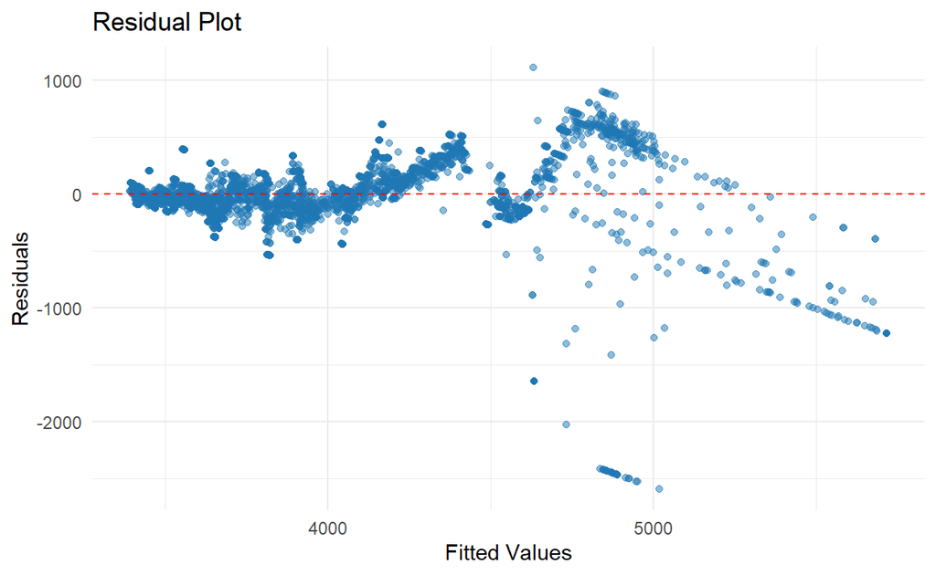

Figure 1: Residual Plot of the Linear Model

```r
# Create a data frame of fitted values and residuals
residuals_data <- data.frame(
  fitted = lr_model$fitted.values,
  residuals = lr_model$residuals
)

# Create the residual plot using ggplot2
ggplot(residuals_data, aes(x = fitted, y = residuals)) +
  geom_point(alpha = 0.5, color = "#1F77B4") +  # Scatter plot of residuals
  geom_hline(yintercept = 0, linetype = "dashed", color = "red") +  # Horizontal line at 0
  labs(
    title = "Residual Plot",
    x = "Fitted Values",
    y = "Residuals"
    ) +
    theme_minimal()
```

As seen in Figure 1, the residuals are tightly clustered arount zero for fitted values below 4500, indicating good model fit in this range, which does not quite hold anymore for fitted values above 4500.

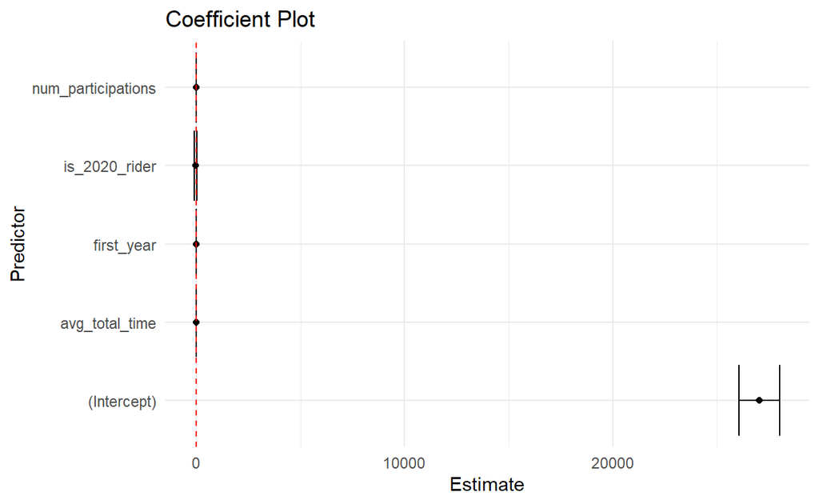

Figure 2: Coefficient Plot of the Linear Model

```r
tidy_model <- broom::tidy(lr_model, conf.int = TRUE)

ggplot(tidy_model, aes(x = estimate, y = term)) +
  geom_point() +
  geom_errorbarh(aes(xmin = conf.low, xmax = conf.high)) +
  geom_vline(xintercept = 0, linetype = "dashed", color = "red") +
  theme_minimal() +
  labs(
    title = "Coefficient Plot",
       x = "Estimate",
       y = "Predictor"
    )
```

## Exercise 2: Logistic Regression (5 Points)

In this exercise we will use the `House Sales in King County, USA` dataset, which includes real property data for residential homes sold between May 2014 and May 2015. The dataset is uploaded to moodle and called `kc_house_data.csv`.

1. Load the data into R and create a new binary variable that indicates whether the price of a house is above average or not, based on the price variable. It should be 1 if the price is above the average, and 0 otherwise. This will serve as the dependent variable for the logistic regression.

```r
library(readr)
library(dplyr)

# Load the data
kc <- read_csv("data/kc_house_data.csv")

# Calculating average price
avg_price <- mean(kc$price)
kc <- kc %>% mutate(price_above_avg = if_else(price > avg_price, 1, 0))
```

2. Select at least 3 variables that you would like to include in a logistic regression on your newly created variable. Make a case for each variable why it should be included.

We choose **bedrooms**, **condition** and **year built**.

**Bedrooms**: The number of bedrooms is a key factor in determining a home’s appeal. Larger homes with more bedrooms are generally considered more desirable, as they offer increased space and flexibility for potential buyers or renters.

**Condition**: The condition of the property plays a critical role in its attractiveness. Homes in better condition are more appealing to buyers, as they typically require less immediate maintenance or renovation, enhancing their marketability.

**Year Built**: The age of a home is an important indicator of its modernity and style. Generally, newer homes are more attractive due to contemporary designs, updated features, and adherence to the latest building codes, which often contribute to higher demand.

3. Run the logistic regression with your 3 chosen independent variables and the dependent variable created in a).

```r
logReg_model <- glm(
  price_above_avg ~ bedrooms + condition + yr_built,
  data = kc,
  family = binomial(link = "logit")
  )

summary(logReg_model)
```

```
Call:
glm(formula = price_above_avg ~ bedrooms + condition + yr_built,
    family = binomial(link = "logit"), data = kc)

Coefficients:
              Estimate Std. Error z value Pr(>|z|)
(Intercept) -3.7930926  1.1315646  -3.352 0.000802 ***
bedrooms     0.7145591  0.0181374  39.397  < 2e-16 ***
condition    0.1551743  0.0244898   6.336 2.35e-10 ***
yr_built     0.0001338  0.0005599   0.239 0.811154
---
Signif. codes:  0 '***' 0.001 '**' 0.01 '*' 0.05 '.' 0.1 ' ' 1

(Dispersion parameter for binomial family taken to be 1)

    Null deviance: 28400  on 21612  degrees of freedom
Residual deviance: 26506  on 21609  degrees of freedom
AIC: 26514

Number of Fisher Scoring iterations: 4
```

4. Use the appropriate easystats package to automatically generate a report of the model you created, use the correct function to generate a *shorter version* of this report.

```r
summary(report(logReg_model))
```

```
We fitted a logistic model to predict price_above_avg with bedrooms,
condition and yr_built. The model's explanatory power is weak (Tjur's
R2 = 0.09). The model's intercept is at -3.79 (95% CI [-6.01,
-1.58]). Within this model:

  - The effect of bedrooms is statistically significant and positive
(beta = 0.71, 95% CI [0.68, 0.75], p < .001, Std. beta = 0.66)
  - The effect of condition is statistically significant and positive
(beta = 0.16, 95% CI [0.11, 0.20], p < .001, Std. beta = 0.10)
  - The effect of yr built is statistically non-significant and
positive (beta = 1.34e-04, 95% CI [-9.63e-04, 1.23e-03], p = 0.811,
Std. beta = 3.93e-03)
```

5. Interpret the coefficient for one independent variable of your choice in the logistic regression.

#### Interpretation of the bedrooms Coefficient: Coefficient = 0.71:

This means that for every additional bedroom in the house, the log-odds of the house having a price above average increase by 0.71.

**Effect on odds**: Since we’re dealing with a logistic regression, the coefficient represents the **log-odds**. To interpret it in terms of odds, you can exponentiate the coefficient.

**Odds Ratio =exp(0.71) ≈ 2.04**

This means that for each additional bedroom, the odds of a house having a price above average are approximately **2.04 times** greater.

**Statistical Significance**:

The p-value for bedrooms is less than 0.001 (p < .001), indicating that the effect of bedrooms on the likelihood of a house having a price above average is statistically significant. In other words, the number of bedrooms has a strong relationship with the outcome.

**Interpretation of the Confidence Interval:**

The 95% confidence interval for the coefficient is [0.68, 0.75]. This means we are 95% confident that the true coefficient lies within this range. The positive interval suggests that as the number of bedrooms increases, the likelihood of having a price above average also increases.

6. Create a plot of your choice illustrating one of the effects you saw in the logistic regression. Briefly explain how your plot relates to the logistic regression.

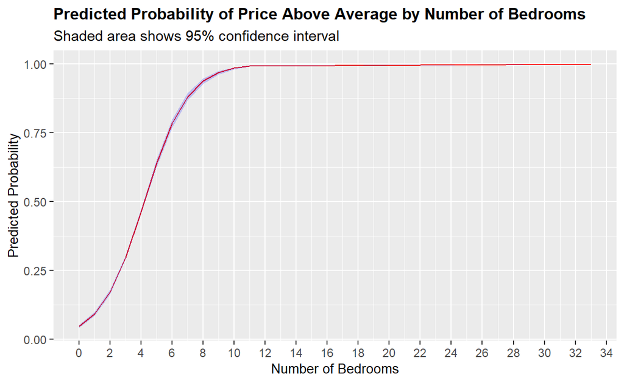

Figure 3: Plot for Predicted Probability of Price Above Average by Number of Bedrooms

```r
# Generate predicted probabilities for bedrooms
bedroom_effect <- ggpredict(logReg_model, terms = "bedrooms")

# Plot
ggplot(bedroom_effect,
       aes(
         x = x,
         y = predicted
       )) +
  geom_line(color = "red", size = 0.5) +
  geom_ribbon(aes(ymin = conf.low, ymax = conf.high), alpha = 0.2, fill = "blue") +
  labs(
    title = "Predicted Probability of Above-Average Price by Number of Bedrooms",
    subtitle = "Shaded area shows 95% confidence interval",
    x = "Number of Bedrooms",
    y = "Predicted Probability"
  ) +
  labs(
    title = "Predicted Probability of Price Above Average by Number of Bedrooms",
    x = "Number of Bedrooms",
    y = "Predicted Probability"
  ) +
  theme(
    plot.title = element_text(size = 12, face = "bold"),
    axis.title = element_text(size = 10),
    axis.text = element_text(size = 9)
  ) +
  scale_x_continuous(breaks = seq(0, 34, by = 2))
```

The Figure 3 shows how the predicted probability of a house being priced above the average changes with the number of bedrooms, while holding the other variables (condition and yr_built) constant at their average values.

The curve reflects the logistic transformation of the linear predictor.

The upward trend confirms the positive coefficient found in the logistic regression summary: more bedrooms increase the likelihood of the house being above average in price.

The confidence band around the line indicates the uncertainty in the predicted probabilities, which is very narrow in the plot 3.

## Exercise 3: Python (2 Points)

Let’s repeat one of the exercise tasks in Python to see the differences between the two programming languages.

Note: We are aware that setting up Python can be a bit tricky and therefore also provide the option of using Google Collab[^1] in case you have issues with installing Python. In that case please post a *screenshot* of your Google Collab notebook below and also upload the raw Notebook as an `ipynb` file. We strongly suggest trying to get Python running on your local machine, however, as it will be a much smoother setup.

Let’s go back to the `LeTourDataSet` (https://github.com/thomascamminady/LeTourDataSet) dataset and repeat the following tasks in Python:

1. Load the dataset as a pandas DataFrame and display the first 10 lines.

```r
#install.packages("reticulate")
library(reticulate)

#reticulate::install_miniconda()
#reticulate::conda_install("r-reticulate", "pandas")
#reticulate::conda_install("r-reticulate", "jinja2")
```

```python
import pandas as pd

df_men = pd.read_csv(
  "https://raw.githubusercontent.com/thomascamminady/LeTourDataSet/master/data/TDF_Riders_History.csv")
df_women = pd.read_csv(
  "https://raw.githubusercontent.com/thomascamminady/LeTourDataSet/master/data/TDFF_Riders_History.csv")

# Showing First 10 lines female and male riders.
df_men[["Rank", "Rider", "Team", "Year", "Distance (km)"]].head(10).style \
    .set_caption("Male Riders") \
    .set_table_styles([
        {"selector": "table", "props": [("font-size", "8px")]}
    ])
```

Male Riders

|  | Rank | Rider | Team | Year | Distance (km) |
| --- | --- | --- | --- | --- | --- |
| 0 | 1 | MAURICE GARIN | TDF 1903 *** | 1903 | 2428 |
| 1 | 2 | LUCIEN POTHIER | TDF 1903 *** | 1903 | 2428 |
| 2 | 3 | FERNAND AUGEREAU | TDF 1903 *** | 1903 | 2428 |
| 3 | 4 | RODOLPHE MULLER | TDF 1903 *** | 1903 | 2428 |
| 4 | 5 | JEAN-BAPTISTE FISCHER | TDF 1903 *** | 1903 | 2428 |
| 5 | 6 | MARCEL KERFF | TDF 1903 *** | 1903 | 2428 |
| 6 | 7 | DIT SAMSON JULIEN LOOTENS | TDF 1903 *** | 1903 | 2428 |
| 7 | 8 | GEORGES PASQUIER | TDF 1903 *** | 1903 | 2428 |
| 8 | 9 | FRANÇOIS BEAUGENDRE | TDF 1903 *** | 1903 | 2428 |
| 9 | 10 | ALOIS CATTEAU | TDF 1903 *** | 1903 | 2428 |

```python
df_women[["Rank", "Rider", "Team", "Year", "Distance (km)"]].head(10).style \
    .set_caption("Female Riders") \
    .set_table_styles([
        {"selector": "table", "props": [("font-size", "8px")]}
    ])
```

Female Riders

|  | Rank | Rider | Team | Year | Distance (km) |
| --- | --- | --- | --- | --- | --- |
| 0 | 1 | ANNEMIEK VAN VLEUTEN | MOVISTAR TEAM WOMEN | 2022 | 1029 |
| 1 | 2 | DEMI VOLLERING | TEAM SD WORX | 2022 | 1029 |
| 2 | 3 | KATARZYNA NIEWIADOMA | CANYON // SRAM RACING | 2022 | 1029 |
| 3 | 4 | JULIETTE LABOUS | TEAM DSM | 2022 | 1029 |
| 4 | 5 | SILVIA PERSICO | VALCAR - TRAVEL & SERVICE | 2022 | 1029 |
| 5 | 6 | ELISA LONGO BORGHINI | TREK - SEGAFREDO | 2022 | 1029 |
| 6 | 7 | CECILIE LUDWIG | FDJ SUEZ FUTUROSCOPE | 2022 | 1029 |
| 7 | 8 | EVITA MUZIC | FDJ SUEZ FUTUROSCOPE | 2022 | 1029 |
| 8 | 9 | VERONICA EWERS | EF EDUCATION-TIBCO-SVB | 2022 | 1029 |
| 9 | 10 | MAVI GARCIA CAÑELLAS | UAE TEAM ADQ | 2022 | 1029 |

2. Create the same variables as in Exercise 1b), but using Python.

```python
# Calculating of total distance
rider_men_summary_py = (
    df_men.groupby("Rider", as_index=False)
    .agg(total_distance=pd.NamedAgg(column="Distance (km)", aggfunc="sum"))
)

# Arranging Rows desc.
rider_men_summary_py = rider_men_summary_py.sort_values(by="total_distance", ascending=False)

rider_men_summary_py.head(10).style.set_caption(
    "Top-10 Riders by Total Distance Across All Participated Years"
)
```

Top-10 Riders by Total Distance Across All Participated Years

|  | Rider | total_distance |
| --- | --- | --- |
| 2195 | LUCIEN VAN IMPE | 59312 |
| 1833 | JOOP ZOETEMELK | 58719 |
| 3289 | SYLVAIN CHAVANEL | 55926 |
| 3457 | VJATCESLAV EKIMOV | 55191 |
| 3275 | STUART O'GRADY | 53691 |
| 230 | ANDRÉ DARRIGADE | 53007 |
| 3337 | THOMAS VOECKLER | 52908 |
| 1419 | HAIMAR ZUBELDIA | 52611 |
| 2946 | RAYMOND POULIDOR | 50544 |
| 1770 | JENS VOIGT | 50152 |

```python
rider_men_summary_py = (
    df_men.groupby("Rider", as_index=False)
    .agg(
        total_distance=("Distance (km)", "sum"),
        years_raced=("Year", "nunique")
    )
)
rider_men_summary_py["avg_distance_per_year"] = (
    rider_men_summary_py["total_distance"] / rider_men_summary_py["years_raced"]
).round(2)

overall_avg = rider_men_summary_py["avg_distance_per_year"].mean()
print("Average distance of all riders' average distance per year: " + str((overall_avg).round(2)) + "km")
```

```
Average distance of all riders' average distance per year: 4022.81km
```

```python
# Arranging Rows desc.
rider_men_summary_py = rider_men_summary_py.sort_values(by="total_distance", ascending=False)

rider_men_summary_py["above_average"] = (
    rider_men_summary_py["avg_distance_per_year"] > overall_avg
).astype(int)

rider_men_summary_py.head(10).style.set_caption("Top-10 Riders by Average Distance Across All Participated Years")
```

|  | Rider | total_distance | years_raced | avg_distance_per_year | above_average |
| --- | --- | --- | --- | --- | --- |
| 2195 | LUCIEN VAN IMPE | 59312 | 15 | 3954.130000 | 0 |
| 1833 | JOOP ZOETEMELK | 58719 | 15 | 3914.600000 | 0 |
| 3289 | SYLVAIN CHAVANEL | 55926 | 16 | 3495.380000 | 0 |
| 3457 | VJATCESLAV EKIMOV | 55191 | 15 | 3679.400000 | 0 |
| 3275 | STUART O'GRADY | 53691 | 15 | 3579.400000 | 0 |
| 230 | ANDRÉ DARRIGADE | 53007 | 12 | 4417.250000 | 1 |
| 3337 | THOMAS VOECKLER | 52908 | 15 | 3527.200000 | 0 |
| 1419 | HAIMAR ZUBELDIA | 52611 | 15 | 3507.400000 | 0 |
| 2946 | RAYMOND POULIDOR | 50544 | 12 | 4212.000000 | 1 |
| 1770 | JENS VOIGT | 50152 | 14 | 3582.290000 | 0 |

[^1]: You can also use a different online Python environment if you prefer, but please talk to us before doing that so we can agree that it is OK.